# A Look at San Francisco Housing Prices on Zillow.com

# STA 141B Spring 2021 Final Project

# By Jennifer Li (999339769) & Miguel Morales (914249562)

# Introduction

In this project, we will be taking a look at housing prices in 2021 for San Francisco, CA from the website Zillow.com. We want to know if factors, such as location, amount of bed/bathrooms, listing company, type of building, total square footage, have any affect on the listed price for a property in San Francisco, CA on Zillow.com. [San Francisco is notorious for having higher prices for properties and many people are unable to afford housing in the Bay Area in 2021.](https://www.vox.com/2019/3/19/18256378/tech-worker-afford-buy-homes-san-francisco-facebook-google-uber-lyft-housing-crisis-programmers) We will use the data available on Zillow's website for sold and currently for sale properties in San Francisco.

# Background

We collected our data directly from Zillow.com, using these following links:

- [For homes that were sold in San Francisco in the past month of May-June 2021.](https://www.zillow.com/san-francisco-ca/sold/)
- [For homes that are currently on sale in San Francisco in June 2021.](https://www.zillow.com/san-francisco-ca/sale/)

For each of the datasets we created, we extracted the following variables from Zillow's website:

- `Address`: The address of the property including its zip code.
- `Listing by`: The property company and agent that listed the property on Zillow.com
- `Price`: The price that the property was listed for.
- `Beds`: The amount of bedrooms the property has.
- `Baths`: The amount of bathrooms the property has.
- `Sqft`: The total amount of square footage the property has.
- `Building Type` (Only for sale homes): The type of home (Condo, Foreclosure, House, Lot/Land, Multi-family home, New construction, Townhouse)

If a home was missing any information, we omitted them from the dataframe used in drawing our conclusions. For example, if certain homes were missing their address for homes that were sold in the last month, we would omit these homes from our dataframe when finding what location had the most homes that sold.

# Analysis

From the San Francisco listings for sale on Zillow.com, we saw from our first bar graph that the most common property type being sold is a condo, followed by houses, and multi-family homes.

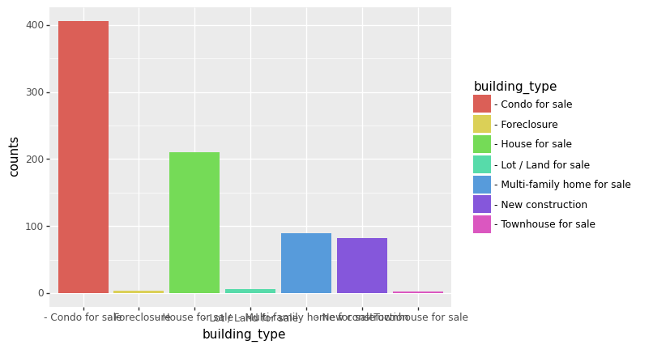

We also saw that the zip code with the most amount of listings was 94110, followed closely by 94109, whereas the zip codes 94130, 94111, and 94104 had the least amount of listings available on Zillow.

We also saw that the average listing price was \$2,191,533 where as the median listing price was \\$1,299,000, with the zip code 94123 being the most expensive area in San Francisco. Whereas for homes that had already sold in the past month, the average price it was sold for was \$1,408,904, and the median was \\$1,275,000.

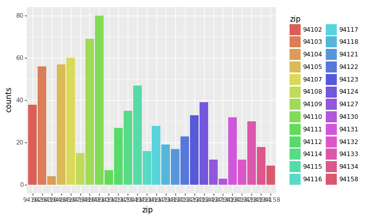

For listings for sale and for sold homes, we saw the brokerage company Compass exceed all other competitors in amount of listings currently available on Zillow. At about 3 times less than the number of Compass listings, Vangaurd Properties and Sotheby's International Realty come in at second and third.

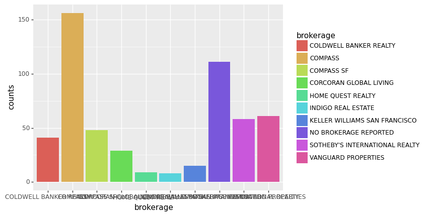

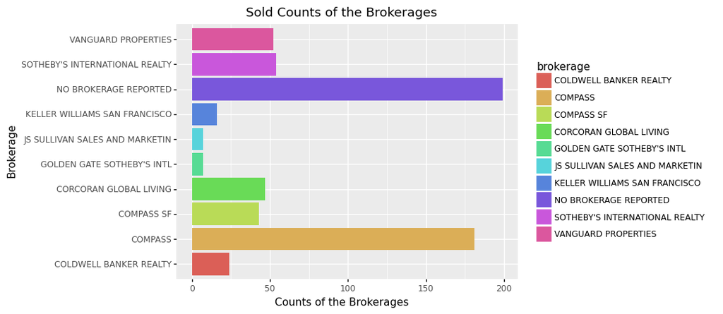

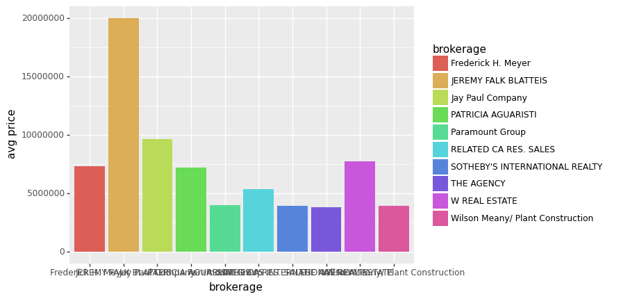

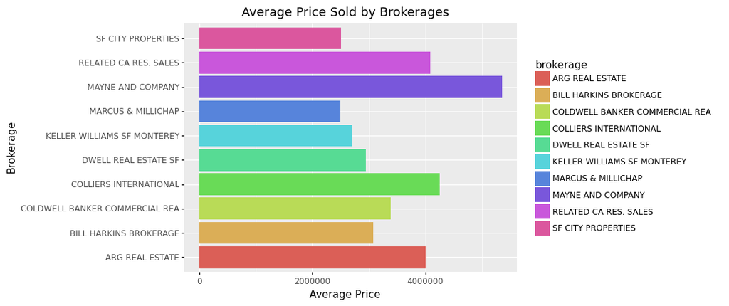

We did see a difference in who currently had the most listings for sale on Zillow, which was Robert Belli, but the agent who had the most sold amount of listing on Zillow in the past month was Frank A. Nolan. What is interesting is that we did see the realtor agent Gregg Lynn with 5 current for sale listings and 5 sold listings on Zillow, and Mollie W. Poe with 8 current for sale listings and 5 sold listings on Zillow.

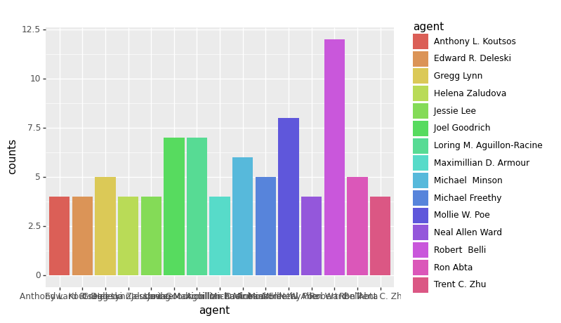

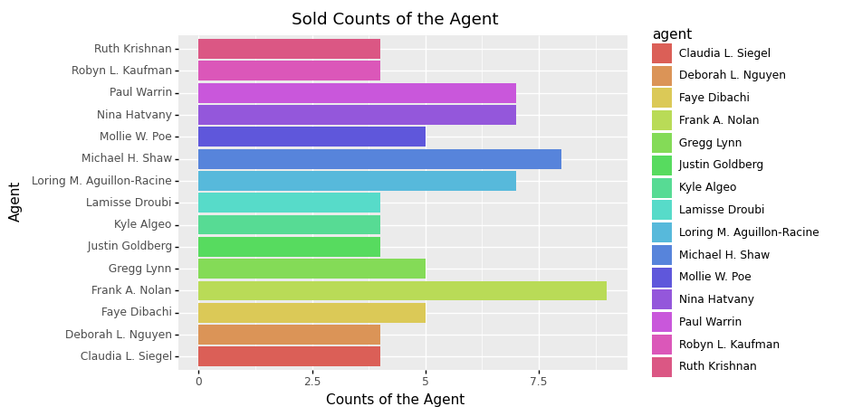

In both listings that had sold and are currently for sale, we saw that square footage had the strongest correlation with a property's listing/sold at price. From this, it is apparent that prices for property listings in San Francisco is most affected by the total amount of square footage the property has, followed by the number of bathrooms, number of bedrooms, and lastly zip code.

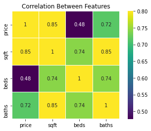

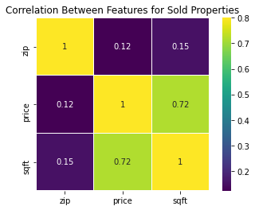

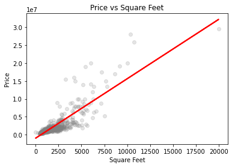

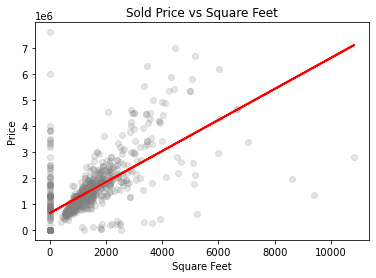

We can see that the zip code 94123 had the highest average price for listing for sale on Zillow (and largest range for prices, which makes sense as this area borders the beach and neighbors the Golden Gate Bridge), followed by zip codes 94118 and 94130.

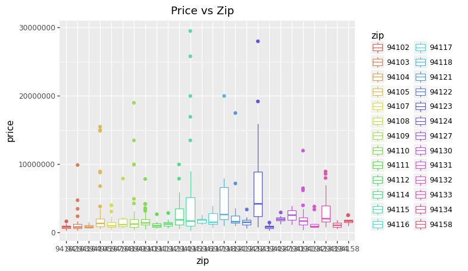

We also saw that homes that were foreclosed upon had the highest price and amount of square footage with condos being the lowest, which is interesting since foreclosure is defined as the legal process by which a lender attempts to recover the amount owed on a defaulted loan by taking ownership of and selling the mortgaged property.

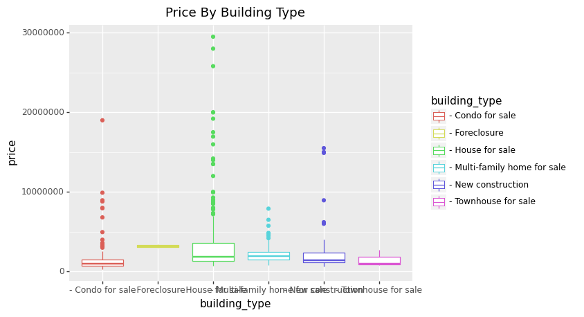

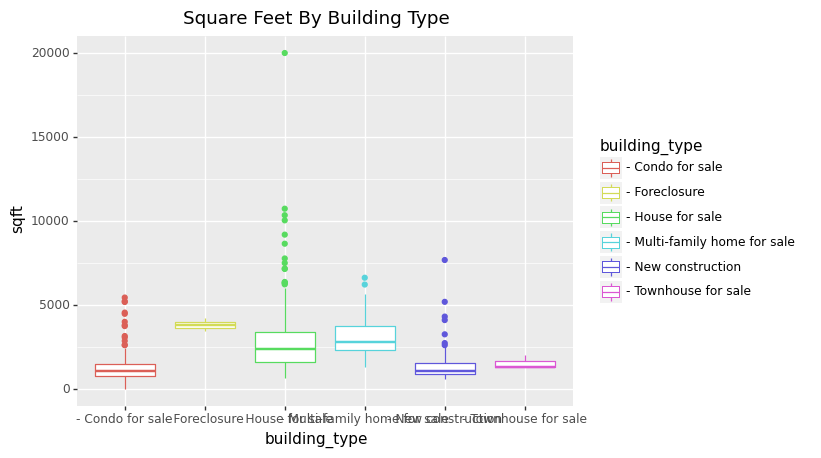

We can see a cluster for homes for sale that have less than 5000 square feet that is mostly made up of condos and houses, with houses having the greatest amount of square footage beyond that (as can be seen through the outliers shown below), which makes sense a house would have a greater square footage than a condo.

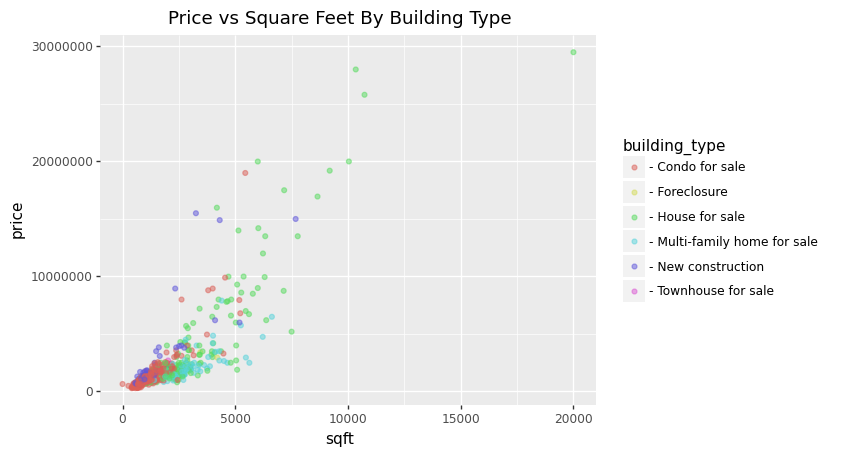

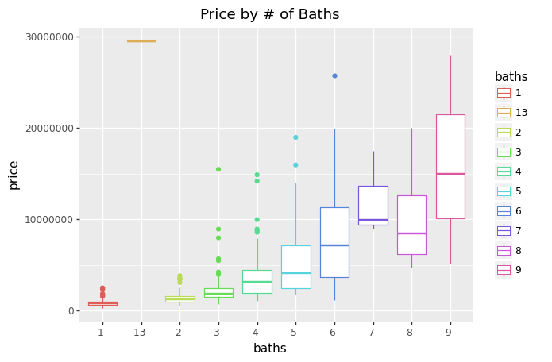

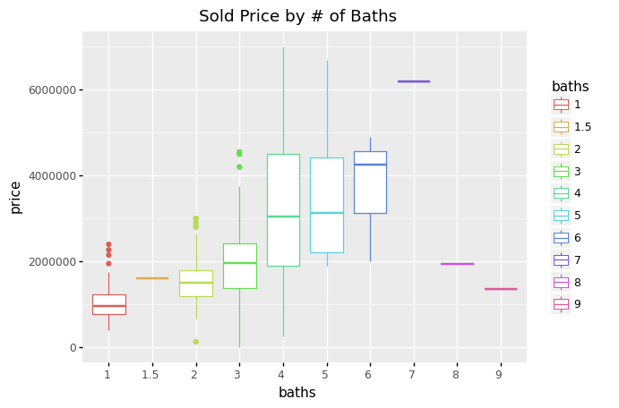

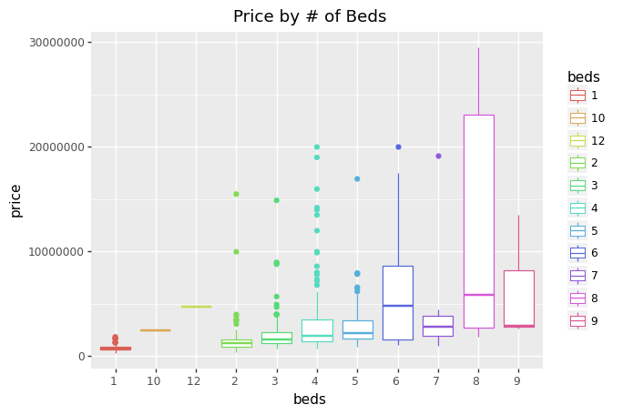

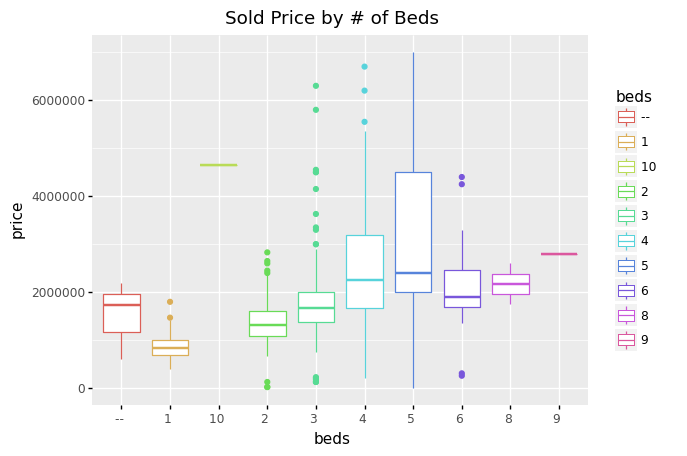

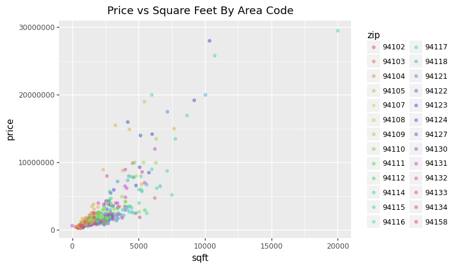

# Conclusion

From our findings, we saw that square footage had the most impact on the price of a property on Zillow.com in San Francisco in June 2021. We also saw that Zillow had more listings for sale from the 94110 zip code in San Francisco, which is located in the Inner Mission/Bernal Heights district, and from this [crime data source](https://www.neighborhoodscout.com/ca/san-francisco/crime), we can see that this area in San Francisco experiences a higher crime rate than its eastern neighbors, which compliments our findings. We also saw that San Francisco had more condos for sale than any other type of property, which makes sense with San Francisco's current dense neighborhoods.

It would be interesting to use our model to predict what homes were likely to be sold/rented out next based on our previous findings. Real estate companies could also use our findings to better understand what factors should be included in their listing in order to make the property more likely to sell or be rented out, such as the total amount of square footage.

Some caveats to our approach would be that we did not compare it to a different year's housing market, such as prices for San Francisco listings before the COVID-19 pandemic--[which had a major impact on the housing market](https://www.wsj.com/articles/the-pandemic-ignited-a-housing-boombut-its-different-from-the-last-one-11615824558), or compare it to other major cities in California, such as Los Angeles, CA. We were also limited to what Zillow had available on their website: 800 results per each search result (i.e. 800 listings San Francisco homes sold in the past month and 800 listings for homes currently for sale), and these search results only provided the aforementioned variables.